# IODS course project

# Chapter 3: Logistic regression

Data creation R script:  
https://github.com/tnissinen/IODS-project/blob/master/data/create_alc.R

### Loading and checking the structure of the data

```r
setwd("~/IODS-project")
library(dplyr)
library(tidyr)
library(ggplot2)
alc <- read.csv("~/IODS-project/data/alc.csv")
```

```r
# structure of the data (all integers except gender that is "F"/"M")
colnames(alc)
```

```
##  [1] "school"     "sex"        "age"        "address"    "famsize"
##  [6] "Pstatus"    "Medu"       "Fedu"       "Mjob"       "Fjob"
## [11] "reason"     "nursery"    "internet"   "guardian"   "traveltime"
## [16] "studytime"  "failures"   "schoolsup"  "famsup"     "paid"
## [21] "activities" "higher"     "romantic"   "famrel"     "freetime"
## [26] "goout"      "Dalc"       "Walc"       "health"     "absences"
## [31] "G1"         "G2"         "G3"         "alc_use"    "high_use"
```

```r
glimpse(alc)
```

```
## Observations: 382
## Variables: 35
## $ school     <fct> GP, GP, GP, GP, GP, GP, GP, GP, GP, GP, GP, GP, GP,...
## $ sex        <fct> F, F, F, F, F, M, M, F, M, M, F, F, M, M, M, F, F, ...
## $ age        <int> 18, 17, 15, 15, 16, 16, 16, 17, 15, 15, 15, 15, 15,...
## $ address    <fct> U, U, U, U, U, U, U, U, U, U, U, U, U, U, U, U, U, ...
## $ famsize    <fct> GT3, GT3, LE3, GT3, GT3, LE3, LE3, GT3, LE3, GT3, G...
## $ Pstatus    <fct> A, T, T, T, T, T, T, A, A, T, T, T, T, T, A, T, T, ...
## $ Medu       <int> 4, 1, 1, 4, 3, 4, 2, 4, 3, 3, 4, 2, 4, 4, 2, 4, 4, ...
## $ Fedu       <int> 4, 1, 1, 2, 3, 3, 2, 4, 2, 4, 4, 1, 4, 3, 2, 4, 4, ...
## $ Mjob       <fct> at_home, at_home, at_home, health, other, services,...
## $ Fjob       <fct> teacher, other, other, services, other, other, othe...
## $ reason     <fct> course, course, other, home, home, reputation, home...
## $ nursery    <fct> yes, no, yes, yes, yes, yes, yes, yes, yes, yes, ye...
## $ internet   <fct> no, yes, yes, yes, no, yes, yes, no, yes, yes, yes,...
```

[output cut: 22 more lines]

The dataset contains 382 observations with 35 variables

4 interesting variables: activities - extra-curricular activities (binary: yes or no) romantic - with a romantic relationship (binary: yes or no) failures - number of past class failures (numeric: n if 1<=n<3, else 4) studytime - weekly study time (numeric: 1 - <2 hours, 2 - 2 to 5 hours, 3 - 5 to 10 hours, or 4 - >10 hours)

My hypothesis activities, romantic relationship and higher studytime will correlate negatively with alcohol consumption. Failures will probably correlate positively with alcohol consumption.

### Distributions and relatioships of the selected variables

Distributions

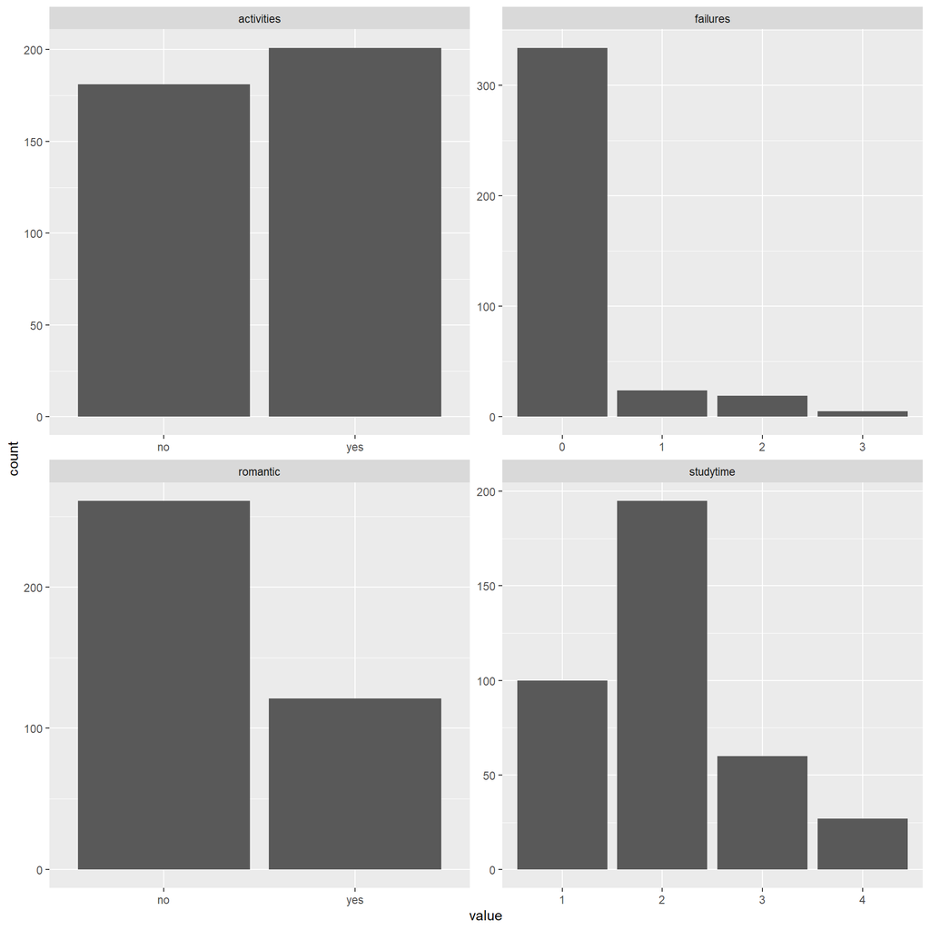

```r
alc_selected <- select(alc, one_of(c("activities", "romantic", "failures", "studytime")))
gather(alc_selected) %>% ggplot(aes(value)) + facet_wrap("key", scales = "free") + geom_bar()
```

Relationships with high alcohol usage

Activities

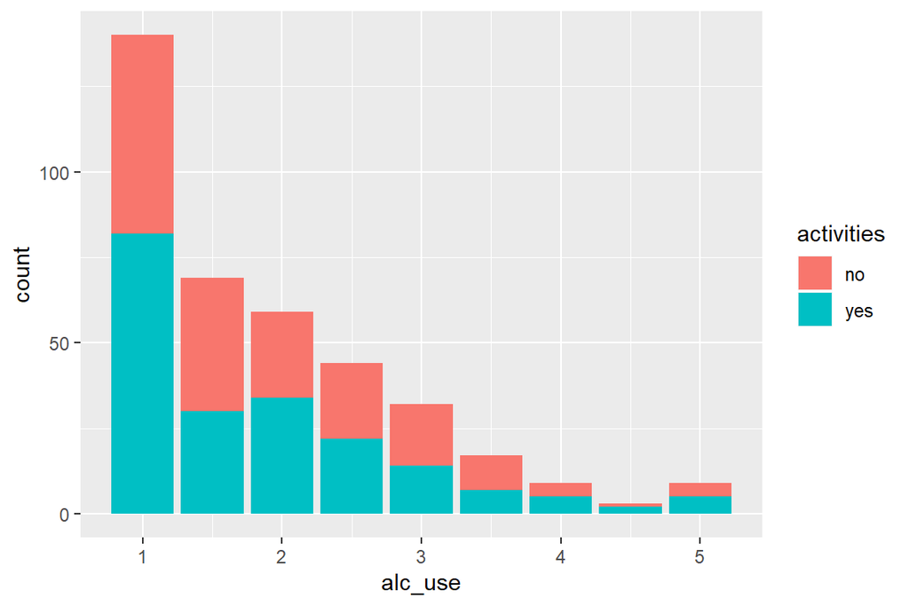

```r
g1 <- ggplot(data = alc, aes(x = alc_use, fill = activities))
g1 + geom_bar()
```

Romantic

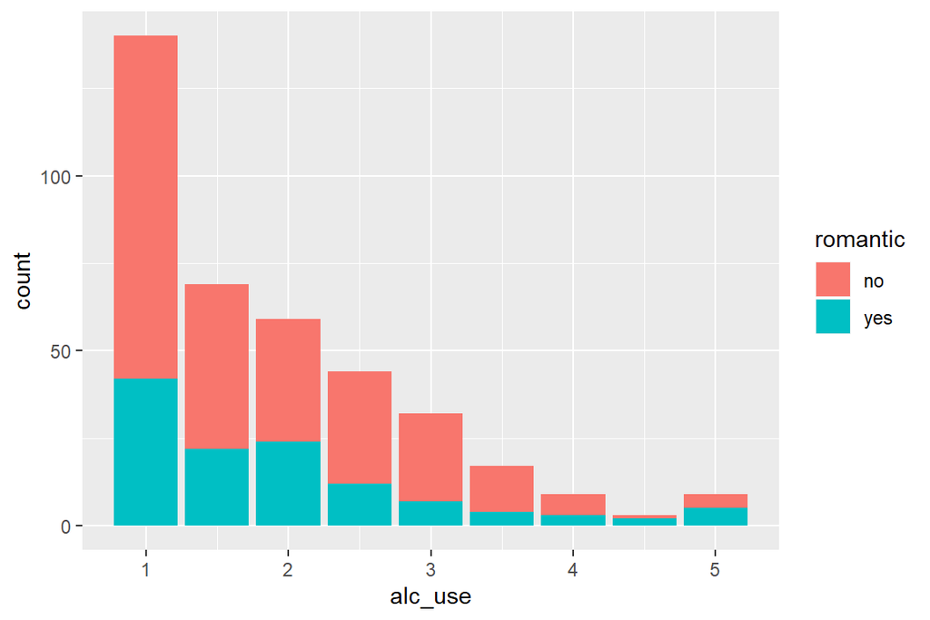

```r
g1 <- ggplot(data = alc, aes(x = alc_use, fill = romantic))
g1 + geom_bar()
```

Failures

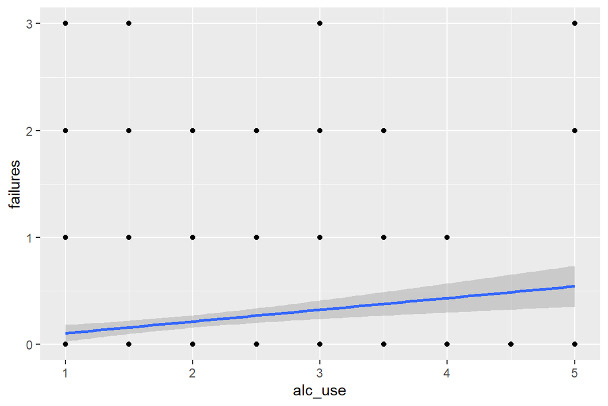

```r
qplot(alc_use, failures, data = alc) + geom_smooth(method = "lm")
```

Studytime

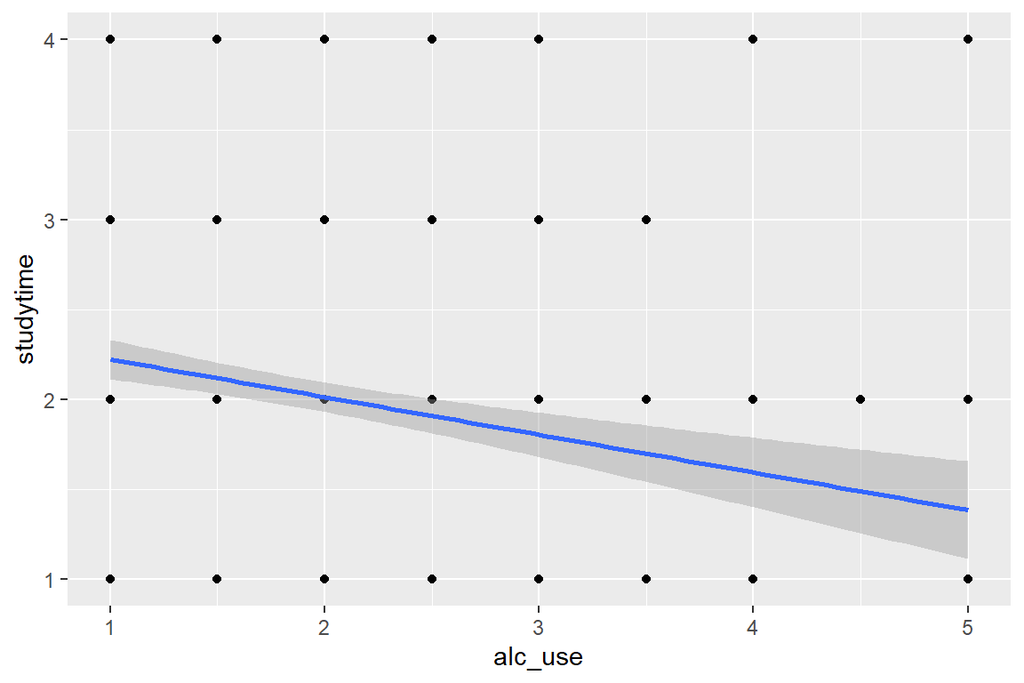

```r
qplot(alc_use, studytime, data = alc) + geom_smooth(method = "lm")
```

### Logistic regression for exploring the relationships

Summary of my explanatory variables coefficients:

```r
# find the model with glm()
m <- glm(high_use ~ failures + activities + studytime + romantic + failures, data = alc, family = "binomial")

# print out a summary of the model
results <- summary(m)

# print out a summary of the model
knitr::kable(results$coefficients, digits=3, caption="Coefficients")
```

Coefficients

|  | Estimate | Std. Error | z value | Pr(>\|z\|) |
| --- | --- | --- | --- | --- |
| (Intercept) | 0.194 | 0.344 | 0.563 | 0.573 |
| failures | 0.377 | 0.188 | 2.007 | 0.045 |
| activitiesyes | -0.142 | 0.232 | -0.611 | 0.541 |
| studytime | -0.520 | 0.156 | -3.327 | 0.001 |
| romanticyes | -0.147 | 0.251 | -0.586 | 0.558 |

We can see that my original hypothesis was correct. Although, only failures and studytime are statistically significant factors (p<0.05).

Odds ratios:

```r
# compute odds ratios (OR)
OR <- coef(m) %>% exp

# compute confidence intervals (CI)
CI <- confint(m) %>% exp

# print out the odds ratios with their confidence intervals
results <- cbind(OR, CI)

# print
knitr::kable(results, digits=3, caption="Odds ratios")
```

Odds ratios

|  | OR | 2.5 % | 97.5 % |
| --- | --- | --- | --- |
| (Intercept) | 1.214 | 0.620 | 2.393 |
| failures | 1.458 | 1.011 | 2.123 |
| activitiesyes | 0.868 | 0.551 | 1.368 |
| studytime | 0.595 | 0.434 | 0.801 |
| romanticyes | 0.863 | 0.523 | 1.405 |

### Analysis of the predictive power of the model

```r
# predict() the probability of high_use
probabilities <- predict(m, type = "response")

# add the predicted probabilities to 'alc'
alc <- mutate(alc, probability = probabilities)

# use the probabilities to make a prediction of high_use
alc <- mutate(alc, prediction = probability > 0.5)

# tabulate the target variable versus the predictions
results <- table(high_use = alc$high_use, prediction = alc$prediction)

knitr::kable(results, digits=3, caption="Tabulate the target variable versus the predictions")
```

Tabulate the target variable versus the predictions

|  | FALSE | TRUE |
| --- | --- | --- |
| FALSE | 260 | 8 |
| TRUE | 103 | 11 |

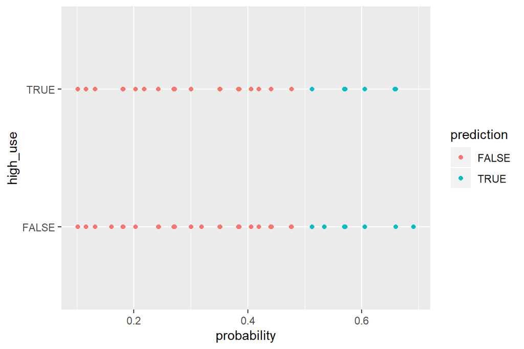

```r
g <- ggplot(alc, aes(x = probability, y = high_use, col = prediction))

# define the geom as points and draw the plot
g + geom_point()
```

```r
# tabulate the target variable versus the predictions
tab <- table(high_use = alc$high_use, prediction = alc$prediction) %>% prop.table() %>% addmargins()


knitr::kable(tab, digits=3, caption="Tabulate the target variable versus the predictions (proportions)")
```

Tabulate the target variable versus the predictions (proportions)

|  | FALSE | TRUE | Sum |
| --- | --- | --- | --- |
| FALSE | 0.681 | 0.021 | 0.702 |
| TRUE | 0.270 | 0.029 | 0.298 |
| Sum | 0.950 | 0.050 | 1.000 |

Total proportion of inaccurately classified individuals:

```r
v <- as.vector(table(high_use = alc$high_use, prediction = alc$prediction))
v2 <- (v[2]+v[3])/(v[1]+v[2]+v[3]+v[4])
v2
```

```
## [1] 0.2905759
```

…

# Chapter 4: Clustering and classification

### Loading and checking the structure of the data

```r
# access the MASS package
library(MASS)
library(dplyr)
library(tidyr)
library(corrplot)
library(ggplot2)
```

```r
# load the data
data("Boston")

# explore the dataset
str(Boston)
```

```
## 'data.frame':    506 obs. of  14 variables:
##  $ crim   : num  0.00632 0.02731 0.02729 0.03237 0.06905 ...
##  $ zn     : num  18 0 0 0 0 0 12.5 12.5 12.5 12.5 ...
##  $ indus  : num  2.31 7.07 7.07 2.18 2.18 2.18 7.87 7.87 7.87 7.87 ...
##  $ chas   : int  0 0 0 0 0 0 0 0 0 0 ...
##  $ nox    : num  0.538 0.469 0.469 0.458 0.458 0.458 0.524 0.524 0.524 0.524 ...
##  $ rm     : num  6.58 6.42 7.18 7 7.15 ...
##  $ age    : num  65.2 78.9 61.1 45.8 54.2 58.7 66.6 96.1 100 85.9 ...
##  $ dis    : num  4.09 4.97 4.97 6.06 6.06 ...
##  $ rad    : int  1 2 2 3 3 3 5 5 5 5 ...
##  $ tax    : num  296 242 242 222 222 222 311 311 311 311 ...
##  $ ptratio: num  15.3 17.8 17.8 18.7 18.7 18.7 15.2 15.2 15.2 15.2 ...
##  $ black  : num  397 397 393 395 397 ...
##  $ lstat  : num  4.98 9.14 4.03 2.94 5.33 ...
##  $ medv   : num  24 21.6 34.7 33.4 36.2 28.7 22.9 27.1 16.5 18.9 ...
```

```r
summary(Boston)
```

```
##       crim                zn             indus            chas
##  Min.   : 0.00632   Min.   :  0.00   Min.   : 0.46   Min.   :0.00000
##  1st Qu.: 0.08204   1st Qu.:  0.00   1st Qu.: 5.19   1st Qu.:0.00000
##  Median : 0.25651   Median :  0.00   Median : 9.69   Median :0.00000
##  Mean   : 3.61352   Mean   : 11.36   Mean   :11.14   Mean   :0.06917
##  3rd Qu.: 3.67708   3rd Qu.: 12.50   3rd Qu.:18.10   3rd Qu.:0.00000
##  Max.   :88.97620   Max.   :100.00   Max.   :27.74   Max.   :1.00000
##       nox               rm             age              dis
##  Min.   :0.3850   Min.   :3.561   Min.   :  2.90   Min.   : 1.130
##  1st Qu.:0.4490   1st Qu.:5.886   1st Qu.: 45.02   1st Qu.: 2.100
##  Median :0.5380   Median :6.208   Median : 77.50   Median : 3.207
##  Mean   :0.5547   Mean   :6.285   Mean   : 68.57   Mean   : 3.795
##  3rd Qu.:0.6240   3rd Qu.:6.623   3rd Qu.: 94.08   3rd Qu.: 5.188
##  Max.   :0.8710   Max.   :8.780   Max.   :100.00   Max.   :12.127
##       rad              tax           ptratio          black
##  Min.   : 1.000   Min.   :187.0   Min.   :12.60   Min.   :  0.32
##  1st Qu.: 4.000   1st Qu.:279.0   1st Qu.:17.40   1st Qu.:375.38
##  Median : 5.000   Median :330.0   Median :19.05   Median :391.44
##  Mean   : 9.549   Mean   :408.2   Mean   :18.46   Mean   :356.67
##  3rd Qu.:24.000   3rd Qu.:666.0   3rd Qu.:20.20   3rd Qu.:396.23
##  Max.   :24.000   Max.   :711.0   Max.   :22.00   Max.   :396.90
##      lstat            medv
##  Min.   : 1.73   Min.   : 5.00
##  1st Qu.: 6.95   1st Qu.:17.02
##  Median :11.36   Median :21.20
##  Mean   :12.65   Mean   :22.53
##  3rd Qu.:16.95   3rd Qu.:25.00
##  Max.   :37.97   Max.   :50.00
```

The dataset contains housing values in suburbs of Boston. It has 506 observations with 14 variables. It also contains the crime rate per capita by town.

### Graphical overview of the data

The plot matrix of the variables:

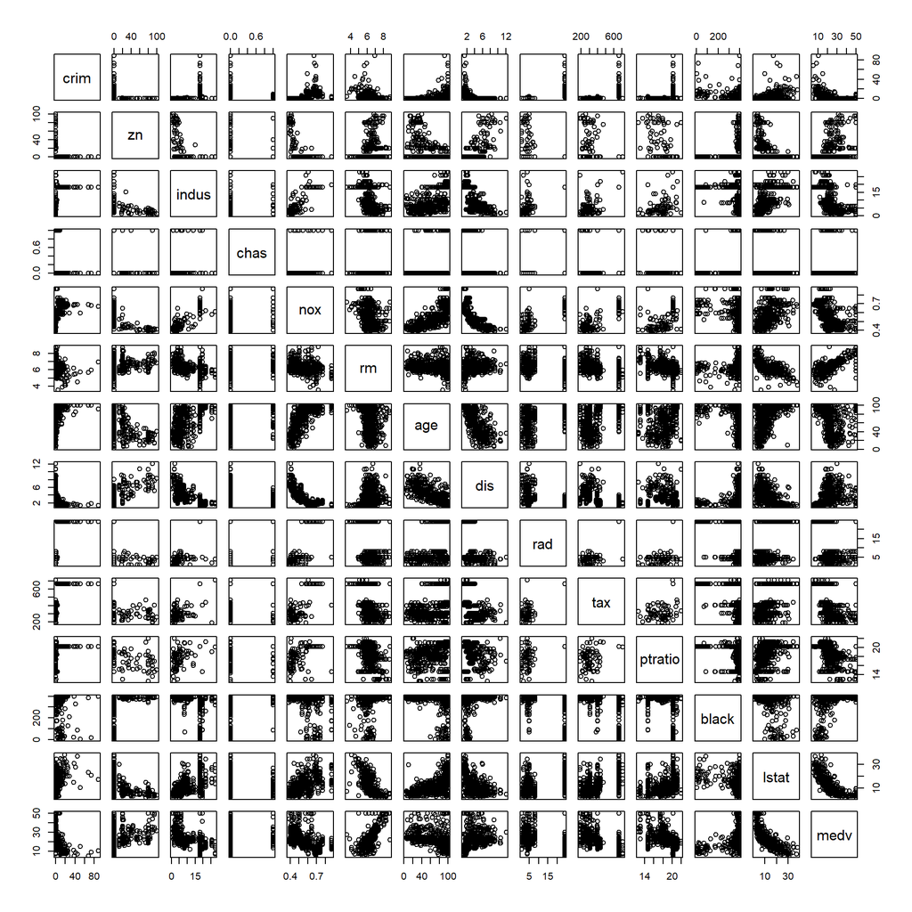

```r
# plot matrix of the variables
pairs(Boston)
```

Three clear correlations pop up from the matrix. Let’s take a closer look…